# CS 422 Homework 3

### Part 2.1-II

```r
print(summary(linear_regression_model_2))
```

```
##
## Call:
## lm(formula = mpg ~ year + origin + displacement, data = train.df)
##
## Residuals:
##      Min       1Q   Median       3Q      Max
## -10.9498  -2.3007  -0.2763   1.9642  14.2026
##
## Coefficients:
##                Estimate Std. Error t value Pr(>|t|)
## (Intercept)  -22.498041   4.785690  -4.701 3.66e-06 ***
## year           0.688341   0.059213  11.625  < 2e-16 ***
## origin         1.430914   0.320950   4.458 1.10e-05 ***
## displacement  -0.044196   0.002617 -16.886  < 2e-16 ***
## ---
## Signif. codes:  0 '***' 0.001 '**' 0.01 '*' 0.05 '.' 0.1 ' ' 1
##
## Residual standard error: 3.919 on 368 degrees of freedom
## Multiple R-squared:  0.7494, Adjusted R-squared:  0.7473
## F-statistic: 366.8 on 3 and 368 DF,  p-value: < 2.2e-16
```

```r
#number of predictors
p <- 3
#number of observations
n <- nrow(train.df)

#hint was definitely taken into account
R_squared <- summary(linear_regression_model_2)$r.squared
Adj_R_squared <- summary(linear_regression_model_2)$adj.r.squared

RSS <- sum(resid(linear_regression_model_2)^2)
RSE <- sqrt(RSS/(n-p-1))
RMSE <- sqrt(RSS/n)
mean_mpg <- mean(Auto$mpg)
percentage_error = round(RSE/mean_mpg * 100, 2)

cat("R-sq value is", round(R_squared, 2), "\n",
    "Adjusted R-sq value is", round(Adj_R_squared, 2), "\n",
    "RSE is", round(RSE, 2), "\n",
    "RMSE is", round(RMSE, 2), "\n",
    "Percentage error of RSE is", paste0(percentage_error, "%"), "\n")
```

```
## R-sq value is 0.75
##  Adjusted R-sq value is 0.75
##  RSE is 3.92
##  RMSE is 3.9
##  Percentage error of RSE is 16.72%
```

#### Since the adjusted R^2 value is (R^2=0.75), this means that roughly 75% of the variance is accounted for by the model. Roughly 25% cannot be explained by the model, which is a small amount. In terms of RSE and RSME, these pretty much tell us a similar thing. The RSE tells us the average amount that the models predictions deviate from the mpg values, while the RSME tells us the average magnitude of the errors. Since, the percentage error relative to the mean mpg is small (16.72%), this is a small margin of error, and thus, still a good model, in terms of all the variables(R^2, RSE, RSME) values. Though, the other model is slighly better since it has a lower percentage error, and more of the variance is accounted for.

### Part 2.1-III

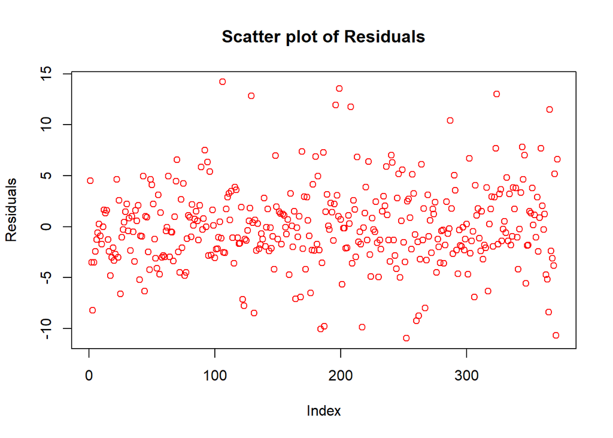

```r
plot(linear_regression_model_2$residuals, ylab = "Residuals", main = "Scatter plot of Residuals", col = 'red')
```

### Part 2.1-IV

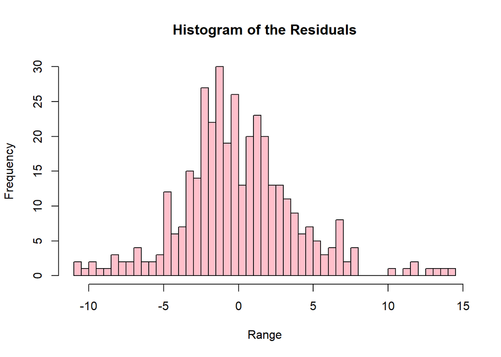

```r
library(nortest)
hist(linear_regression_model_2$residuals, freq = TRUE, xlab = "Range", main = "Histogram of the Residuals", breaks = 80, col = 'pink')
```

```r
residuals <- residuals(linear_regression_model_2)
shapiro_test <- shapiro.test(residuals)
print(shapiro_test)
```

```
##
##  Shapiro-Wilk normality test
##
## data:  residuals
## W = 0.97251, p-value = 1.693e-06
```

```r
anderson_test <- ad.test(residuals)
print(anderson_test)
```

```
##
##  Anderson-Darling normality test
##
## data:  residuals
## A = 2.5928, p-value = 1.495e-06
```

### Part 2.1-C

```r
confidence_data <- predict(linear_regression_model_2, newdata = test.df, interval = "confidence")
confidence_data_frame <- data.frame(prediction = confidence_data[,1],
                                    response = test.df$mpg,
                                    lower = confidence_data[,2],
                                    upper = confidence_data[,3])

matches_c <- apply(confidence_data_frame, 1, function(x) x[2] > x[3] && x[2] < x[4])
confidence_data_frame$match <- as.integer(as.logical(matches_c))
print(confidence_data_frame)
```

```
##     prediction response     lower    upper match
## 23   23.951243     25.0 22.962994 24.93949     0
## 86   13.713119     13.0 12.984598 14.44164     1
## 96    9.072532     12.0  7.921095 10.22397     0
## 111  27.270394     22.0 26.336253 28.20454     0
## 121  25.264932     19.0 24.593979 25.93588     0
## 140  16.522871     14.0 15.946434 17.09931     0
## 153  20.614308     19.0 20.111689 21.11693     0
## 161  20.349132     17.0 19.851781 20.84648     0
## 176  28.011691     29.0 27.379323 28.64406     0
## 178  26.906790     23.0 26.350702 27.46288     0
## 179  26.685809     23.0 26.142601 27.22902     0
## 189  17.192415     16.0 16.547162 17.83767     0
## 259  22.414154     20.6 21.850176 22.97813     0
## 279  30.120909     31.5 29.544070 30.69775     0
## 302  28.671199     34.2 27.830566 29.51183     0
## 319  30.939681     29.8 29.987592 31.89177     0
## 343  28.721999     30.0 27.875243 29.56875     0
## 345  30.887606     39.0 29.913865 31.86135     0
## 348  33.793629     37.0 32.861125 34.72613     0
## 359  32.246767     31.6 31.265617 33.22792     1
```

### Part 2.1-D

```r
matches_c <- sum(confidence_data_frame$match, na.rm = FALSE)
cat("Total observations correctly predicted:",matches_c)
```

```
## Total observations correctly predicted: 2
```

### Part 2-E

```r
prediction_data <- predict(linear_regression_model_2, newdata = test.df, interval = "prediction")
prediction_data_frame <- data.frame(prediction = prediction_data[,1],
                                    response = test.df$mpg,
                                    lower = prediction_data[,2],
                                    upper = prediction_data[,3])

matches_p <- apply(prediction_data_frame, 1, function(x) x[2] > x[3] && x[2] < x[4])
prediction_data_frame$match <- as.integer(as.logical(matches_p))
print(prediction_data_frame)
```

```
##     prediction response     lower    upper match
## 23   23.951243     25.0 16.181419 31.72107     1
## 86   13.713119     13.0  5.972042 21.45420     1
## 96    9.072532     12.0  1.280271 16.86479     1
## 111  27.270394     22.0 19.507267 35.03352     1
## 121  25.264932     19.0 17.529061 33.00080     1
## 140  16.522871     14.0  8.794623 24.25112     1
## 153  20.614308     19.0 12.891216 28.33740     1
## 161  20.349132     17.0 12.626381 28.07188     1
## 176  28.011691     29.0 20.279071 35.74431     1
## 178  26.906790     23.0 19.180034 34.63355     1
## 179  26.685809     23.0 18.959969 34.41165     1
## 189  17.192415     16.0  9.458730 24.92610     1
## 259  22.414154     20.6 14.686826 30.14148     1
## 279  30.120909     31.5 22.392632 37.84919     1
## 302  28.671199     34.2 20.918768 36.42363     1
## 319  30.939681     29.8 23.174374 38.70499     1
## 343  28.721999     30.0 20.968901 36.47510     1
## 345  30.887606     39.0 23.119614 38.65560     0
## 348  33.793629     37.0 26.030699 41.55656     1
## 359  32.246767     31.6 24.477843 40.01569     1
```

```r
matches_p <- sum(prediction_data_frame$match, na.rm = FALSE)
cat("Total observations correctly predicted:",matches_p)
```

```
## Total observations correctly predicted: 19
```

### Part 2.1-F

```r
#### (i) e came out with more matches
#### (ii) e came out with more matches because the prediction interval is generally wider than a confidence interval since it accounts for the extra uncertainty associated with predicting a new observation rather than estimating the population parameter.
```